# Simple statistical test

## Univariate

There are two options for doing univariate analysis. You can use the `gtsummary` package or you can use the individual regression functions available in `base` together with the `broom` package.

### `gtsummary` package

```r
univ_tab <- linelist %>%
  ## select variables of interest
  select(explanatory_vars, outcome) %>%
  ## produce univariate table
  tbl_uvregression(
    ## define regression want to run (generalised linear model)
    method = glm,
    ## define outcome variable
    y = outcome,
    ## define what type of glm want to run (logistic)
    method.args = list(family = binomial),
    ## exponentiate the outputs to produce odds ratios (rather than log odds)
    exponentiate = TRUE
    )

## view univariate results table
univ_tab
```

| **Characteristic** | **N** | **OR**<sup>1</sup> | **95% CI**<sup>1</sup> | **p-value** |
| --- | --- | --- | --- | --- |
| gender | 4,172 | 0.99 | 0.88, 1.12 | >0.9 |
| fever | 4,172 | 1.03 | 0.89, 1.20 | 0.7 |
| chills | 4,172 | 1.02 | 0.88, 1.19 | 0.8 |
| cough | 4,172 | 1.01 | 0.85, 1.20 | >0.9 |
| aches | 4,172 | 0.89 | 0.72, 1.08 | 0.2 |
| vomit | 4,172 | 0.99 | 0.87, 1.12 | 0.8 |
| age_cat | 4,172 |  |  |  |
| 0-4 |  | — | — |  |
| 5-9 |  | 1.04 | 0.86, 1.27 | 0.7 |
| 10-14 |  | 1.03 | 0.84, 1.27 | 0.8 |
| 15-19 |  | 1.09 | 0.88, 1.35 | 0.4 |
| 20-29 |  | 1.02 | 0.84, 1.25 | 0.8 |
| 30-49 |  | 1.03 | 0.81, 1.30 | 0.8 |
| 50-69 |  | 1.47 | 0.73, 3.12 | 0.3 |

<sup>*1*</sup> OR = Odds Ratio, CI = Confidence Interval

### `base`

Using the `glm` function from the **stats** package (part of base R), you can produce odds ratios.

For a single exposure variable, pass the names to `glm` and then use `tidy` from the **broom** package to get the exponentiated odds ratio estimates and confidence intervals. Here we demonstrate how to combine model outputs with a table of counts.

```r
model <- glm(
  ## define the variables of interest
  outcome ~ age_cat,
  ## define the type of regression (logistic)
  family = "binomial",
  ## define your dataset
  data = linelist) %>%
  ## clean up the outputs of the regression (exponentiate and produce CIs)
  tidy(
      exponentiate = TRUE,
      conf.int = TRUE)


linelist %>%
  ## get counts of variable of interest grouped by outcome
  group_by(outcome) %>%
  count(age_cat) %>%
  ## spread to wide format (as in cross-tabulation)
  pivot_wider(names_from = outcome, values_from = n) %>%
  ## drop rows with missings
  filter(!is.na(age_cat)) %>%
  ## merge with the outputs of the regression
  bind_cols(., model) %>%
  ## only keep columns interested in
  select(term, 2:3, estimate, conf.low, conf.high, p.value)
```

```
## # A tibble: 7 x 7
##   term           `0`   `1` estimate conf.low conf.high p.value
##   <chr>        <int> <int>    <dbl>    <dbl>     <dbl>   <dbl>
## 1 (Intercept)    354   440     1.24    1.08       1.43 0.00232
## 2 age_cat5-9     357   462     1.04    0.855      1.27 0.688
## 3 age_cat10-14   306   393     1.03    0.842      1.27 0.754
## 4 age_cat15-19   259   352     1.09    0.884      1.35 0.411
## 5 age_cat20-29   346   439     1.02    0.837      1.25 0.839
## 6 age_cat30-49   189   241     1.03    0.810      1.30 0.832
## 7 age_cat50-69    12    22     1.47    0.732      3.12 0.288
```

To run over several exposure variables to produce univariate odds ratios (i.e. not controlling for each other), you can pass a vector of variable names to the `map` function in the **purrr** package. This will loop over each of the variables running regressions for each one.

```r
models <- explanatory_vars %>%
  ## combine each name of the variables of interest with the name of outcome variable
  str_c("outcome ~ ", .) %>%
  ## for each string above (outcome ~ "variable of interest)
  map(
    ## run a general linear model
    ~glm(
      ## define formula as each of the strings above
      as.formula(.x),
      ## define type of glm (logistic)
      family = "binomial",
      ## define your dataset
      data = linelist)
  ) %>%
  ## for each of the output regressions from above
  map(
    ## tidy the output
    ~tidy(
      ## each of the regressions
      .x,
      ## exponentiate and produce CIs
      exponentiate = TRUE,
      conf.int = TRUE)
  ) %>%
  ## collapse the list of regressions outputs in to one data frame
  bind_rows()



## for each explanatory variable
univ_tab_base <- map(explanatory_vars,
      ~{linelist %>%
          ## group data set by outcome
          group_by(outcome) %>%
          ## produce counts for variable of interest
          count(.data[[.x]]) %>%
          ## spread to wide format (as in cross-tabulation)
          pivot_wider(names_from = outcome, values_from = n) %>%
          ## drop rows with missings
          filter(!is.na(.data[[.x]])) %>%
          ## change the variable of interest column to be called "variable"
          rename("variable" = .x) %>%
          ## change the variable of interest column to be a character
          ## otherwise non-dichotomous (categorical) variables come out as factor and cant be merged
          mutate(variable = as.character(variable))
                 }
      ) %>%
  ## collapse the list of count outputs in to one data frame
  bind_rows() %>%
  ## merge with the outputs of the regression
  bind_cols(., models) %>%
  ## only keep columns interested in
  select(term, 2:3, estimate, conf.low, conf.high, p.value)
```

[output not shown]

## Stratified

Stratified analysis is currently still being worked on for `gtsummary`, this page will be updated in due course.

## Multivariable

```r
## run a regression with all variables of interest
mv_reg <- explanatory_vars %>%
  ## combine all names of the variables of interest separated by a plus
  str_c(collapse = "+") %>%
  ## combined the names of variables of interest with outcome in formula style
  str_c("outcome ~ ", .) %>%
  glm(## define type of glm (logistic)
      family = "binomial",
      ## define your dataset
      data = linelist)

## choose a model using forward selection based on AIC
## you can also do "backward" or "both" by adjusting the direction
final_mv_reg <- mv_reg %>%
  step(direction = "forward", trace = FALSE)
```

### `gtsummary` package

The `gtsummary` package provides the `tbl_regression` function, which will take the outputs from a regression (`glm` in this case) and produce an easy summary table. You can also combine several different output tables produced by `gtsummary` with the `tbl_mege` function.

```r
## show results table of final regression
mv_tab <- tbl_regression(final_mv_reg, exponentiate = TRUE)

## combine with univariate results
tbl_merge(
  tbls = list(univ_tab, mv_tab),
  tab_spanner = c("**Univariate**", "**Multivariable**"))
```

| **Characteristic** | **Univariate** **N** | **Univariate** **OR**<sup>1</sup> | **Univariate** **95% CI**<sup>1</sup> | **Univariate** **p-value** | **Multivariable** **OR**<sup>1</sup> | **Multivariable** **95% CI**<sup>1</sup> | **Multivariable** **p-value** |
| --- | --- | --- | --- | --- | --- | --- | --- |
| gender | 4,172 | 0.99 | 0.88, 1.12 | >0.9 | 0.99 | 0.87, 1.12 | 0.9 |
| fever | 4,172 | 1.03 | 0.89, 1.20 | 0.7 | 1.03 | 0.89, 1.20 | 0.7 |
| chills | 4,172 | 1.02 | 0.88, 1.19 | 0.8 | 1.02 | 0.88, 1.19 | 0.8 |
| cough | 4,172 | 1.01 | 0.85, 1.20 | >0.9 | 1.01 | 0.85, 1.20 | >0.9 |
| aches | 4,172 | 0.89 | 0.72, 1.08 | 0.2 | 0.88 | 0.72, 1.08 | 0.2 |
| vomit | 4,172 | 0.99 | 0.87, 1.12 | 0.8 | 0.98 | 0.87, 1.11 | 0.8 |
| age_cat | 4,172 |  |  |  |  |  |  |
| 0-4 |  | — | — |  | — | — |  |
| 5-9 |  | 1.04 | 0.86, 1.27 | 0.7 | 1.05 | 0.86, 1.27 | 0.7 |
| 10-14 |  | 1.03 | 0.84, 1.27 | 0.8 | 1.04 | 0.84, 1.27 | 0.7 |
| 15-19 |  | 1.09 | 0.88, 1.35 | 0.4 | 1.10 | 0.89, 1.36 | 0.4 |
| 20-29 |  | 1.02 | 0.84, 1.25 | 0.8 | 1.02 | 0.84, 1.25 | 0.8 |
| 30-49 |  | 1.03 | 0.81, 1.30 | 0.8 | 1.03 | 0.81, 1.31 | 0.8 |
| 50-69 |  | 1.47 | 0.73, 3.12 | 0.3 | 1.48 | 0.73, 3.14 | 0.3 |

<sup>*1*</sup> OR = Odds Ratio, CI = Confidence Interval

### `base`

```r
mv_tab_base <- final_mv_reg %>%
  ## get a tidy dataframe of estimates
  broom::tidy(exponentiate = TRUE, conf.int = TRUE)

## combine univariate and multivariable tables
left_join(univ_tab_base, mv_tab_base, by = "term") %>%
  ## choose columns and rename them
  select(
    "characteristic" = term,
    "recovered"      = "0",
    "dead"           = "1",
    "univ_or"        = estimate.x,
    "univ_ci_low"    = conf.low.x,
    "univ_ci_high"   = conf.high.x,
    "univ_pval"      = p.value.x,
    "mv_or"          = estimate.y,
    "mvv_ci_low"     = conf.low.y,
    "mv_ci_high"     = conf.high.y,
    "mv_pval"        = p.value.y
  )
```

```
## # A tibble: 19 x 11
##    characteristic recovered  dead univ_or univ_ci_low univ_ci_high univ_pval
##    <chr>              <int> <int>   <dbl>       <dbl>        <dbl>     <dbl>
##  1 (Intercept)          913  1180   1.29        1.19          1.41  5.88e- 9
##  2 gender               910  1169   0.994       0.879         1.12  9.22e- 1
##  3 (Intercept)          377   474   1.26        1.10          1.44  9.07e- 4
##  4 fever               1446  1875   1.03        0.886         1.20  6.90e- 1
##  5 (Intercept)         1469  1885   1.28        1.20          1.37  7.80e-13
##  6 chills               354   464   1.02        0.876         1.19  7.87e- 1
##  7 (Intercept)          263   337   1.28        1.09          1.51  2.58e- 3
##  8 cough               1560  2012   1.01        0.845         1.20  9.42e- 1
##  9 (Intercept)         1629  2125   1.30        1.22          1.39  6.93e-16
## 10 aches                194   224   0.885       0.723         1.08  2.38e- 1
## 11 (Intercept)          927  1202   1.30        1.19          1.41  2.79e- 9
## 12 vomit                896  1147   0.987       0.874         1.12  8.37e- 1
## 13 (Intercept)          354   440   1.24        1.08          1.43  2.32e- 3
## 14 age_cat5-9           357   462   1.04        0.855         1.27  6.88e- 1
## 15 age_cat10-14         306   393   1.03        0.842         1.27  7.54e- 1
## 16 age_cat15-19         259   352   1.09        0.884         1.35  4.11e- 1
## 17 age_cat20-29         346   439   1.02        0.837         1.25  8.39e- 1
## 18 age_cat30-49         189   241   1.03        0.810         1.30  8.32e- 1
## 19 age_cat50-69          12    22   1.47        0.732         3.12  2.88e- 1
## # ... with 4 more variables: mv_or <dbl>, mvv_ci_low <dbl>, mv_ci_high <dbl>,
## #   mv_pval <dbl>
```

## Forest plot

### `ggplot2` package

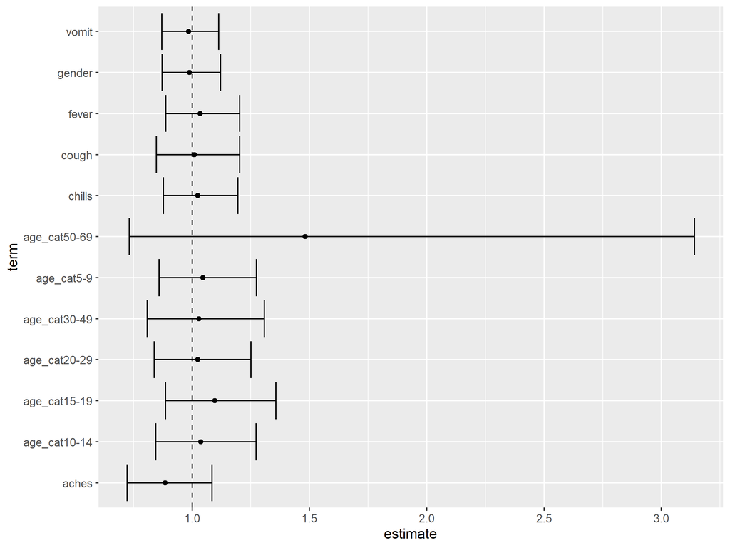

```r
## remove the intercept term from your multivariable results
mv_tab_base %>%
  filter(term != "(Intercept)") %>%
  ## plot with variable on the y axis and estimate (OR) on the x axis
  ggplot(aes(x = estimate, y = term)) +
  ## show the estimate as a point
  geom_point() +
  ## add in an error bar for the confidence intervals
  geom_errorbar(aes(xmin = conf.low, xmax = conf.high)) +
  ## show where OR = 1 is for reference as a dashed line
  geom_vline(xintercept = 1, linetype = "dashed")
```

### `easytats` packages

The alternative if you do not want to decide all of the different things required for a `ggplot`, is to use a combination of `easystats` packages. In this case the `paramaters` package function `model_paramets` does the equivalent of `broom` package function `tidy`. The `see` package then accepts those outputs and creates a default forest plot as a `ggplot` object.

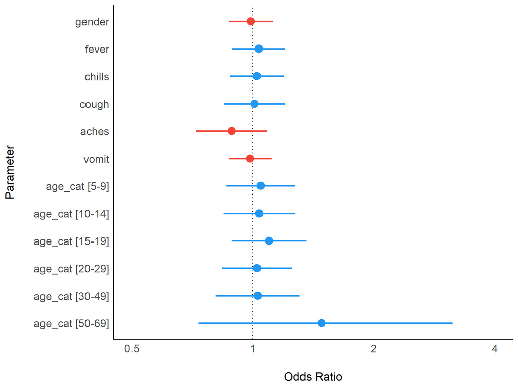

```r
## remove the intercept term from your multivariable results
final_mv_reg %>%
  model_parameters(exponentiate = TRUE) %>%
  plot()
```

## Resources

Much of the information in this page is adapted from these resources and vignettes online:

[gtsummary](http://www.danieldsjoberg.com/gtsummary/articles/tbl_regression.html)

[sthda stepwise regression](http://www.sthda.com/english/articles/36-classification-methods-essentials/150-stepwise-logistic-regression-essentials-in-r/)